# Event layer: marine heatwaves, coral heat stress and tropical cyclones

Independent ground truth for the 14-sanctuary trajectory analysis

The monthly state variables of the manuscript come from a reanalysis. This notebook builds a layer of events that is **independent** of it and is already used by managers: marine heatwave categories (daily satellite SST), coral bleaching heat stress (NOAA Coral Reef Watch) and named storms (IBTrACS). Every download is cached under `data/events/` or `data/raw/` and skipped when present, so the notebook re-renders offline.

```r
librarian::shelf(
  dplyr, ggplot2, glue, heatwaveR, here, httr2, knitr, lubridate, ncdf4, purrr, readr,
  scales, sf, stringr, tibble, tidyr,
  quiet = T)
options(readr.show_col_types = F)

# paths ----
dir_ev     <- here("data/events")
dir_oisst  <- file.path(dir_ev, "oisst")   # kept: OCNMS cross-check only
dir_raw    <- here("data/raw")
dir_fig    <- here("figures/events")
sanc_geo   <- here("data/sanctuaries.geojson")
pnms_geo   <- here("data/state/pnms.geojson")   # Papahanaumokuakea (not in sanctuaries.geojson)
for (d in c(file.path(dir_raw, "crw"), file.path(dir_raw, "ibtracs"), dir_fig))
  dir.create(d, showWarnings = F, recursive = T)
mhw_events_csv  <- file.path(dir_ev, "mhw_events.csv")
mhw_monthly_csv <- file.path(dir_ev, "mhw_monthly.csv")
mhw_annual_csv  <- file.path(dir_ev, "mhw_annual.csv")
dhw_monthly_csv <- file.path(dir_ev, "dhw_monthly.csv")
dhw_annual_csv  <- file.path(dir_ev, "dhw_annual.csv")
storms_csv      <- file.path(dir_ev, "storms.csv")

# constants ----
OSTIA_ID    <- "METOFFICE-GLO-SST-L4-REP-OBS-SST"
SST_START <- as.Date("1982-01-01")
CLIM_PERIOD <- c("1983-01-01", "2012-12-31")
STORM_KM    <- 150
STORM_YEAR  <- 1993
NMS_ORD <- c(
  "OCNMS", "GFNMS", "CBNMS", "MBNMS", "CPNMS", "CINMS", "PNMS", "HIHWNMS", "NMSAS",
  "FGBNMS", "FKNMS", "GRNMS", "MNMS", "SBNMS")
CORAL_NMS <- c("PNMS", "HIHWNMS", "NMSAS", "FGBNMS", "FKNMS")

# plot theme (as trajectory_checks.qmd) ----
PAL <- list(
  surface = "#fcfcfb", ink = "#0b0b0b", ink2 = "#52514e", muted = "#898781",
  grid    = "#e1e0d9", axis = "#c3c2b7", blue = "#2a78d6", orange = "#eb6834")
PAL_SEQ <- c("#f0efec", "#f3b3ad", "#eb6834", "#e34948", "#8f1d1c")
theme_chk <- function(base_size = 10) {
  theme_minimal(base_size = base_size) +
    theme(
      plot.background    = element_rect(fill = PAL$surface, color = NA),
      panel.background   = element_rect(fill = PAL$surface, color = NA),
      panel.grid.major   = element_line(color = PAL$grid, linewidth = 0.25),
      panel.grid.minor   = element_blank(),
      axis.text          = element_text(color = PAL$muted),
      axis.title         = element_text(color = PAL$ink2),
      plot.title         = element_text(color = PAL$ink, face = "bold", size = rel(1.1)),
      plot.subtitle      = element_text(color = PAL$ink2),
      plot.caption       = element_text(color = PAL$muted, hjust = 0),
      plot.title.position = "plot",
      legend.position    = "top",
      legend.justification = "left",
      legend.title       = element_text(color = PAL$ink2),
      legend.text        = element_text(color = PAL$ink2))
}
save_fig <- function(p, name, width = 9, height = 5) {
  ggsave(file.path(dir_fig, name), p, width = width, height = height, dpi = 200, bg = PAL$surface)
  p
}

# download with retries and a polite pause ----
fetch <- function(url, path, tries = 5, pause = 1) {
  request(url) |>
    req_timeout(600) |>
    req_retry(max_tries = 8, is_transient = \(r) resp_status(r) %in% c(408, 429, 500, 502, 503, 504), backoff = \(i) 10 * i) |>
    req_perform(path = path)
  Sys.sleep(pause)
  invisible(path)
}

# sanctuaries, ordered ----
sf_use_s2(FALSE)
sanc <- bind_rows(
  read_sf(sanc_geo) |> select(nms),
  read_sf(pnms_geo) |> select(nms)) |>
  filter(nms %in% NMS_ORD) |>
  mutate(nms = factor(nms, NMS_ORD)) |>
  arrange(nms) |>
  group_by(nms) |>
  summarize(geometry = st_union(geometry), .groups = "drop") |>
  st_make_valid()
stopifnot(nrow(sanc) == 14)
```

## Part 1: marine heatwaves and cold spells

Source: Copernicus Marine `SST_GLO_SST_L4_REP_OBSERVATIONS_010_011`, dataset METOFFICE-GLO-SST-L4-REP-OBS-SST (OSTIA reprocessed daily foundation SST analysis, 0.05°, variable `analysed_sst`; Good et al. 2020, [doi:10.3390/rs12040720](https://doi.org/10.3390/rs12040720)), 1982-01-01 to 2026-03-31. Per sanctuary: the daily mean (converted to °C) of grid cells whose centres fall inside the polygon (Papahanaumokuakea, PNMS, at 1.5 million km2 is instead sampled on a regular 1 degree lattice of OSTIA cells inside the polygon, cos(latitude)-weighted; `n_cells` is the lattice count. Buffered by 10 km for Monitor, Gray’s Reef and Flower Garden Banks, as for the state variables); if none, the cell nearest the polygon centroid. Events follow Hobday et al. (2016, 2018) via `heatwaveR` (climatology 1983-01-01 to 2012-12-31, 90th percentile for heatwaves, 10th for cold spells).

```r
OSTIA_END <- "2026-03-31"
dir_ostia <- file.path(dir_raw, "ostia")
dir_sst   <- file.path(dir_ev, "sst_daily")
dir.create(dir_ostia, showWarnings = F, recursive = T)
dir.create(dir_sst, showWarnings = F, recursive = T)
CMT <- path.expand("~/.virtualenvs/CopernicusMarine/bin/copernicusmarine")

# polygon (buffered 10 km for the three shelf sanctuaries) ----
geom_for <- \(code) {
  g <- sanc$geometry[sanc$nms == code]
  if (code %in% c("MNMS", "GRNMS", "FGBNMS")) {
    sf_use_s2(TRUE); g <- st_buffer(g, 10000); sf_use_s2(FALSE)
  }
  g
}

# one subset request per sanctuary (credentials come from the toolbox config) ----
get_ostia_nc <- \(code) {
  f <- file.path(dir_ostia, glue("{code}.nc"))
  if (file.exists(f)) return(f)
  b <- st_bbox(geom_for(code))
  system2(CMT, c(
    "subset", "-i", OSTIA_ID, "-v", "analysed_sst",
    "--minimum-longitude", b["xmin"] - 0.15, "--maximum-longitude", b["xmax"] + 0.15,
    "--minimum-latitude",  b["ymin"] - 0.15, "--maximum-latitude",  b["ymax"] + 0.15,
    "-t", glue("{SST_START}T00:00:00"), "-T", glue("{OSTIA_END}T00:00:00"),
    "-s", "arco-time-series", "-o", dir_ostia, "-f", glue("{code}.nc"),
    "--overwrite", "--disable-progress-bar"), stdout = F, stderr = F)
  f
}

# daily polygon mean from the netcdf ----
build_sst_daily <- \(code) {
  if (code == "PNMS") return(build_sst_pnms())
  g  <- geom_for(code)
  nc <- nc_open(get_ostia_nc(code))
  on.exit(nc_close(nc))
  lo <- as.vector(ncvar_get(nc, "longitude")); la <- as.vector(ncvar_get(nc, "latitude"))
  tt <- as.Date(as.POSIXct(as.vector(ncvar_get(nc, "time")), origin = "1981-01-01", tz = "UTC"))
  cells <- expand_grid(lat = la, lon = lo)
  pts   <- st_as_sf(cells, coords = c("lon", "lat"), crs = 4326, remove = F)
  inside <- lengths(st_intersects(pts, g)) > 0
  if (!any(inside)) inside <- seq_len(nrow(cells)) == which.min(as.numeric(st_distance(pts, st_centroid(g))))
  mask <- matrix(inside, nrow = length(lo), ncol = length(la))   # expand_grid(lat, lon): lon fastest
  idx  <- split(seq_along(tt), ceiling(seq_along(tt) / 2000))
  map(idx, \(i) {
    a <- ncvar_get(nc, "analysed_sst", start = c(1, 1, min(i)), count = c(-1, -1, length(i)), collapse_degen = F)
    m <- matrix(a, nrow = length(lo) * length(la))[as.vector(mask), , drop = F]
    tibble(date = tt[i], sst = round(colMeans(m, na.rm = T) - 273.15, 3), n_valid = colSums(!is.na(m)))
  }) |> list_rbind() |>
    filter(n_valid > 0) |>
    transmute(date, sst, n_cells = max(n_valid))
}

# PNMS (1.5 million km2): regular 1-degree lattice of points inside the polygon, one single-cell request
# per point (cached in data/raw/ostia/pnms/); cos(latitude)-weighted mean, n_cells = lattice cells ----
build_sst_pnms <- \(code = "PNMS") {
  g   <- sanc$geometry[sanc$nms == "PNMS"]
  lat <- 19:32
  lon <- c(178:179, -180:-161)
  p   <- expand_grid(lon = lon, lat = lat)
  sf_use_s2(TRUE)
  p   <- p[lengths(st_intersects(st_as_sf(p, coords = c("lon", "lat"), crs = 4326), st_make_valid(g))) > 0, ]
  sf_use_s2(FALSE)
  d <- pmap(p, \(lon, lat) {
    f <- file.path(dir_ostia, "pnms", glue("pt_{lon}_{lat}.nc"))
    if (!file.exists(f)) {
      system2(CMT, c(
        "subset", "-i", OSTIA_ID, "-v", "analysed_sst",
        "--minimum-longitude", lon, "--maximum-longitude", lon,
        "--minimum-latitude", lat, "--maximum-latitude", lat,
        "-t", glue("{SST_START}T00:00:00"), "-T", glue("{OSTIA_END}T00:00:00"),
        "-s", "arco-time-series", "-o", dirname(f), "-f", basename(f),
        "--overwrite", "--disable-progress-bar"), stdout = F, stderr = F)
    }
    nc <- nc_open(f); on.exit(nc_close(nc))
    tibble(
      date = as.Date(as.POSIXct(as.vector(ncvar_get(nc, "time")), origin = "1981-01-01", tz = "UTC")),
      sst  = as.vector(ncvar_get(nc, "analysed_sst")) - 273.15,
      w    = cos(lat * pi / 180))
  }) |> list_rbind() |> filter(!is.na(sst))
  d |>
    group_by(date) |>
    summarize(n = n(), sst = round(sum(sst * w) / sum(w), 3), .groups = "drop") |>
    transmute(date, sst, n_cells = max(n))
}

for (code in NMS_ORD) {
  f <- file.path(dir_sst, glue("{code}.csv"))
  if (!file.exists(f)) build_sst_daily(code) |> write_csv(f)
}
NMS_PRESENT <- NMS_ORD
sst_daily <- map(NMS_ORD, \(code) read_csv(file.path(dir_sst, glue("{code}.csv"))) |> mutate(nms = code, .before = 1)) |>
  list_rbind() |>
  mutate(nms = factor(nms, NMS_ORD))
sst_daily |>
  group_by(nms) |>
  summarize(n_cells = max(n_cells), first = min(date), last = max(date), days = n()) |>
  kable(caption = "OSTIA daily series per sanctuary (cells with data).")
```

OSTIA daily series per sanctuary (cells with data).

| nms | n_cells | first | last | days |
| --- | --- | --- | --- | --- |
| OCNMS | 392 | 1982-01-01 | 2026-03-31 | 16161 |
| GFNMS | 354 | 1982-01-01 | 2026-03-31 | 16161 |
| CBNMS | 137 | 1982-01-01 | 2026-03-31 | 16161 |
| MBNMS | 634 | 1982-01-01 | 2026-03-31 | 16161 |
| CPNMS | 766 | 1982-01-01 | 2026-03-31 | 16161 |
| CINMS | 152 | 1982-01-01 | 2026-03-31 | 16161 |
| PNMS | 131 | 1982-01-01 | 2026-03-31 | 16161 |
| HIHWNMS | 123 | 1982-01-01 | 2026-03-31 | 16161 |
| NMSAS | 1168 | 1982-01-01 | 2026-03-31 | 16161 |
| FGBNMS | 248 | 1982-01-01 | 2026-03-31 | 16161 |
| FKNMS | 350 | 1982-01-01 | 2026-03-31 | 16161 |
| GRNMS | 27 | 1982-01-01 | 2026-03-31 | 16161 |
| MNMS | 16 | 1982-01-01 | 2026-03-31 | 16161 |
| SBNMS | 95 | 1982-01-01 | 2026-03-31 | 16161 |

```r
oisst <- sst_daily
```

```r
# detect events per sanctuary ----
detect <- function(d, cold = F) {
  clim <- ts2clm(
    d |> transmute(t = date, temp = sst),
    climatologyPeriod = CLIM_PERIOD, pctile = if (cold) 10 else 90)
  det <- detect_event(clim, coldSpells = cold)
  list(clim = det$climatology, event = det$event)
}

res <- map(NMS_PRESENT, \(code) {
  d  <- oisst |> filter(nms == code) |> arrange(date) |> select(date, sst)
  h  <- detect(d)
  cs <- detect(d, cold = T)
  # hobday 2018 category: floor((temp - seas) / (thresh - seas)), capped at IV (daily, within events)
  hd <- h$clim |>
    mutate(cat = if_else(event, pmin(4, floor((temp - seas) / (thresh - seas))), 0)) |>
    transmute(date = t, mhw = event %in% T, cat = replace_na(cat, 0))
  cd <- cs$clim |> transmute(date = t, mcs = event %in% T)
  # event category from heatwaveR::category (text I-IV)
  cat_ev <- category(list(climatology = h$clim, event = h$event), climatology = F, S = T) |>
    transmute(event_no, category = str_extract(as.character(category), "^[IV]+"))
  ev <- bind_rows(
    h$event |> mutate(kind = "mhw") |> left_join(cat_ev, by = "event_no"),
    cs$event |> mutate(kind = "mcs", category = NA_character_)) |>
    transmute(
      nms = code, kind, date_start, date_peak, date_end, duration,
      intensity_max = round(intensity_max, 3), intensity_cumulative = round(intensity_cumulative, 3),
      category)
  list(events = ev, daily = hd |> left_join(cd, by = "date") |> mutate(nms = code))
})
events <- map(res, "events") |> list_rbind() |> mutate(nms = factor(nms, NMS_ORD)) |> arrange(nms, kind, date_start)
daily  <- map(res, "daily")  |> list_rbind() |>
  left_join(oisst |> mutate(nms = as.character(nms)) |> select(nms, date, sst), by = c("nms", "date"))

# monthly and annual ----
mhw_monthly <- daily |>
  mutate(date = floor_date(date, "month")) |>
  group_by(nms, date) |>
  summarize(
    mhw_days = sum(mhw), mcs_days = sum(mcs, na.rm = T), mhw_max_cat = as.integer(max(cat)),
    sst_daily = round(mean(sst, na.rm = T), 3), .groups = "drop") |>
  mutate(nms = factor(nms, NMS_ORD)) |>
  arrange(nms, date)

ev_year <- events |>
  filter(kind == "mhw") |>
  mutate(year = year(date_peak)) |>
  group_by(nms, year) |>
  summarize(mhw_events = n(), mhw_cum_intensity = round(sum(intensity_cumulative), 2), .groups = "drop")
mhw_annual <- mhw_monthly |>
  mutate(year = year(date)) |>
  group_by(nms, year) |>
  summarize(
    mhw_days = sum(mhw_days), mcs_days = sum(mcs_days), mhw_max_cat = max(mhw_max_cat), .groups = "drop") |>
  left_join(ev_year, by = c("nms", "year")) |>
  mutate(
    mhw_events        = replace_na(mhw_events, 0L),
    mhw_cum_intensity = replace_na(mhw_cum_intensity, 0)) |>
  select(nms, year, mhw_days, mcs_days, mhw_events, mhw_max_cat, mhw_cum_intensity)

events      |> write_csv(mhw_events_csv)
mhw_monthly |> write_csv(mhw_monthly_csv)
mhw_annual  |> write_csv(mhw_annual_csv)
```

Heatwave days by decade (days with SST above the local 90th percentile threshold, in events of 5+ days):

```r
mhw_annual |>
  mutate(decade = glue("{floor(year / 10) * 10}s")) |>
  group_by(nms, decade) |>
  summarize(days = sum(mhw_days), .groups = "drop") |>
  pivot_wider(names_from = decade, values_from = days) |>
  kable(caption = "Total marine heatwave days by decade (1980s from 1982; 2020s to the latest day).")
```

Table 1: Total marine heatwave days by decade (1980s from 1982; 2020s to the latest day).

| nms | 1980s | 1990s | 2000s | 2010s | 2020s |
| --- | --- | --- | --- | --- | --- |
| OCNMS | 114 | 545 | 246 | 658 | 218 |
| GFNMS | 238 | 503 | 154 | 560 | 230 |
| CBNMS | 228 | 496 | 149 | 626 | 207 |
| MBNMS | 298 | 499 | 148 | 610 | 267 |
| CPNMS | 337 | 467 | 118 | 642 | 259 |
| CINMS | 281 | 465 | 125 | 638 | 206 |
| PNMS | 88 | 130 | 455 | 741 | 1035 |
| HIHWNMS | 141 | 312 | 440 | 976 | 561 |
| NMSAS | 28 | 335 | 288 | 582 | 400 |
| FGBNMS | 37 | 186 | 422 | 855 | 1127 |
| FKNMS | 118 | 348 | 289 | 585 | 886 |
| GRNMS | 204 | 309 | 259 | 476 | 428 |
| MNMS | 120 | 247 | 185 | 400 | 301 |
| SBNMS | 18 | 87 | 235 | 1228 | 940 |

```r
mhw_annual |>
  group_by(nms) |>
  slice_max(mhw_days, n = 3, with_ties = F) |>
  summarize(top_years = paste0(year, " (", mhw_days, " d, cat ", mhw_max_cat, ")", collapse = "; ")) |>
  kable(caption = "Three years with the most heatwave days per sanctuary.")
```

Table 2: Three years with the most heatwave days per sanctuary.

| nms | top_years |
| --- | --- |
| OCNMS | 2015 (191 d, cat 2); 1997 (189 d, cat 2); 2016 (158 d, cat 3) |
| GFNMS | 2015 (179 d, cat 3); 2014 (154 d, cat 3); 1997 (144 d, cat 3) |
| CBNMS | 2015 (228 d, cat 3); 2014 (161 d, cat 3); 1997 (142 d, cat 3) |
| MBNMS | 2015 (251 d, cat 3); 1983 (179 d, cat 2); 2014 (174 d, cat 3) |
| CPNMS | 2015 (271 d, cat 2); 1983 (191 d, cat 2); 2014 (171 d, cat 3) |
| CINMS | 2015 (257 d, cat 3); 2014 (177 d, cat 2); 1997 (155 d, cat 2) |
| PNMS | 2025 (283 d, cat 3); 2022 (248 d, cat 2); 2017 (151 d, cat 2) |
| HIHWNMS | 2019 (238 d, cat 4); 2004 (233 d, cat 2); 1996 (191 d, cat 2) |
| NMSAS | 2019 (159 d, cat 2); 2020 (157 d, cat 2); 2010 (119 d, cat 1) |
| FGBNMS | 2025 (295 d, cat 3); 2023 (250 d, cat 2); 2016 (188 d, cat 2) |
| FKNMS | 2023 (242 d, cat 2); 2022 (171 d, cat 2); 2019 (169 d, cat 2) |
| GRNMS | 2020 (106 d, cat 3); 2018 (92 d, cat 2); 2019 (83 d, cat 2) |
| MNMS | 2016 (113 d, cat 2); 2020 (104 d, cat 2); 2015 (79 d, cat 2) |
| SBNMS | 2012 (255 d, cat 4); 2016 (235 d, cat 2); 2023 (229 d, cat 3) |

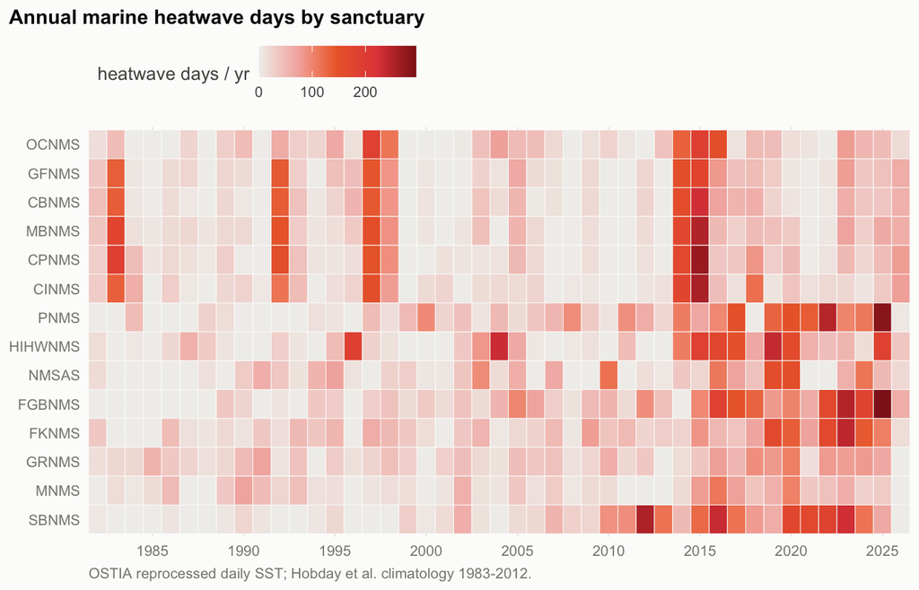

Figure 1

```r
p <- mhw_annual |>
  mutate(nms = factor(nms, rev(NMS_ORD))) |>
  ggplot(aes(year, nms, fill = mhw_days)) +
  geom_tile(color = PAL$surface) +
  scale_fill_gradientn(colors = PAL_SEQ, name = "heatwave days / yr") +
  scale_x_continuous(expand = c(0, 0), breaks = seq(1985, 2025, 5)) +
  labs(x = NULL, y = NULL, title = "Annual marine heatwave days by sanctuary",
       caption = "OSTIA reprocessed daily SST; Hobday et al. climatology 1983-2012.") +
  theme_chk()
save_fig(p, "mhw_annual_days.png", 9, 4.5)
```

### Cross-check against OISST (Olympic Coast)

The earlier OISST v2.1 (0.25°) series for Olympic Coast is kept as a sanity check of the OSTIA-based events.

```r
o <- read_csv(file.path(dir_oisst, "OCNMS.csv")) |> transmute(date, sst)
n <- sst_daily |> filter(nms == "OCNMS") |> transmute(date, sst)
anom <- \(d) ts2clm(d |> transmute(t = date, temp = sst), climatologyPeriod = CLIM_PERIOD) |>
  transmute(date = t, anom = temp - seas)
both <- inner_join(anom(o), anom(n), by = "date", suffix = c("_oisst", "_ostia")) |> drop_na()
hd <- \(d) detect(d)$clim |> filter(event %in% T) |> count(year = year(t), name = "days")
full_join(hd(o) |> rename(oisst_days = days), hd(n) |> rename(ostia_days = days), by = "year") |>
  replace_na(list(oisst_days = 0, ostia_days = 0)) |>
  arrange(year) |>
  filter(oisst_days > 0 | ostia_days > 0) |>
  kable(caption = glue("OCNMS heatwave days per year (daily-anomaly correlation r = {round(cor(both$anom_oisst, both$anom_ostia), 3)}, n = {nrow(both)} days)."))
```

OCNMS heatwave days per year (daily-anomaly correlation r = 0.862, n = 14967 days).

| year | oisst_days | ostia_days |
| --- | --- | --- |
| 1982 | 14 | 13 |
| 1983 | 109 | 47 |
| 1987 | 15 | 24 |
| 1989 | 11 | 30 |
| 1990 | 45 | 47 |
| 1992 | 73 | 64 |
| 1993 | 0 | 29 |
| 1994 | 0 | 23 |
| 1995 | 0 | 67 |
| 1996 | 0 | 11 |
| 1997 | 0 | 189 |
| 1998 | 50 | 115 |
| 1999 | 11 | 0 |
| 2000 | 5 | 0 |
| 2002 | 18 | 2 |
| 2003 | 48 | 43 |
| 2004 | 39 | 76 |
| 2005 | 75 | 49 |
| 2006 | 41 | 46 |
| 2007 | 11 | 19 |
| 2009 | 9 | 11 |
| 2010 | 32 | 25 |
| 2011 | 16 | 6 |
| 2012 | 7 | 0 |
| 2013 | 55 | 41 |
| 2014 | 130 | 133 |
| 2015 | 235 | 191 |
| 2016 | 162 | 158 |
| 2017 | 5 | 9 |
| 2018 | 49 | 50 |
| 2019 | 127 | 45 |
| 2020 | 38 | 14 |
| 2021 | 23 | 7 |
| 2022 | 11 | 0 |
| 2023 | 56 | 79 |
| 2024 | 87 | 54 |
| 2025 | 41 | 48 |
| 2026 | 45 | 16 |

## Part 2: coral heat stress

Source: NOAA Coral Reef Watch 5 km Regional Virtual Stations (daily text files, `coralreefwatch.noaa.gov/product/vs/data/<station>.txt`). Maximum Degree Heating Week (DHW, from the 90th-percentile hot spot) and the 7-day maximum Bleaching Alert Area (BAA) value are summarised by month. In these files BAA is 0 no stress, 1 Watch, 2 Warning, 3 Alert Level 1, 4 Alert Level 2 (5 = Level 3+), so `days_alert1plus` counts days with BAA >= 3.

```r
stations <- tribble(
  ~nms,      ~station,         ~why,
  "FKNMS",   "florida_keys",   "Florida Keys virtual station (middle -81.6, 24.75) covers the Keys reef tract",
  "FGBNMS",  "flower_garden",  "Flower Garden Banks, Texas station (-93.98, 28.05) is the banks themselves",
  "PNMS",    "nwhi",           "Northwestern Hawaiian Islands station (-170.1, 25.7), the only NWHI station; covers the sanctuary reefs",
  "HIHWNMS", "hawaii",         "Main Hawaiian Islands station (-157.7, 20.58) spans Kauai, Oahu, Maui Nui and Hawaii; no finer split exists",
  "NMSAS",   "samoas",         "Samoas station (-170.5, -12.8) covers American Samoa")
stations |> kable(caption = "Virtual stations used per coral sanctuary.")
crw_url <- \(s) glue("https://coralreefwatch.noaa.gov/product/vs/data/{s}.txt")
crw_txt <- \(s) file.path(dir_raw, "crw", glue("{s}.txt"))
for (s in unique(stations$station)) if (!file.exists(crw_txt(s))) fetch(crw_url(s), crw_txt(s))

crw <- map2(stations$nms, stations$station, \(n, s) {
  read_table(I(str_subset(readLines(crw_txt(s)), "^\\d{4} \\d{2} \\d{2} +\\S+ +\\S+")), col_names = c(
    "yy", "mm", "dd", "sst_min", "sst_max", "sst90", "ssta90", "hs", "dhw", "baa"),
    col_types = "iiiddddddi", skip_empty_rows = T, comment = "") |>
    filter(!is.na(yy)) |>
    mutate(nms = n, station = s, date = make_date(yy, mm, dd))
}) |> list_rbind()
```

Table 3: Virtual stations used per coral sanctuary.

| nms | station | why |
| --- | --- | --- |
| FKNMS | florida_keys | Florida Keys virtual station (middle -81.6, 24.75) covers the Keys reef tract |
| FGBNMS | flower_garden | Flower Garden Banks, Texas station (-93.98, 28.05) is the banks themselves |
| PNMS | nwhi | Northwestern Hawaiian Islands station (-170.1, 25.7), the only NWHI station; covers the sanctuary reefs |
| HIHWNMS | hawaii | Main Hawaiian Islands station (-157.7, 20.58) spans Kauai, Oahu, Maui Nui and Hawaii; no finer split exists |
| NMSAS | samoas | Samoas station (-170.5, -12.8) covers American Samoa |

```r
dhw_monthly <- crw |>
  mutate(date = floor_date(date, "month")) |>
  group_by(nms, station, date) |>
  summarize(dhw_max = round(max(dhw), 3), baa_max = max(baa), .groups = "drop") |>
  mutate(nms = factor(nms, NMS_ORD)) |>
  arrange(nms, date)
dhw_annual <- crw |>
  mutate(year = year(date)) |>
  group_by(nms, station, year) |>
  summarize(dhw_max = round(max(dhw), 3), days_alert1plus = sum(baa >= 3), .groups = "drop") |>
  mutate(nms = factor(nms, NMS_ORD)) |>
  arrange(nms, year)
dhw_monthly |> write_csv(dhw_monthly_csv)
dhw_annual  |> write_csv(dhw_annual_csv)

dhw_annual |>
  group_by(year) |>
  filter(max(dhw_max) >= 4) |>
  ungroup() |>
  select(nms, year, dhw_max) |>
  pivot_wider(names_from = nms, values_from = dhw_max) |>
  select(year, any_of(CORAL_NMS)) |>
  kable(caption = "Maximum DHW (degree C-weeks) by year, for years when any coral sanctuary reached 4 or more.")
```

Maximum DHW (degree C-weeks) by year, for years when any coral sanctuary reached 4 or more.

| year | PNMS | HIHWNMS | NMSAS | FGBNMS | FKNMS |
| --- | --- | --- | --- | --- | --- |
| 1991 | 1.051 | 0.000 | 3.970 | 5.627 | 2.201 |
| 1994 | 0.329 | 0.000 | 8.613 | 0.000 | 0.000 |
| 1995 | 0.000 | 0.000 | 3.391 | 4.444 | 0.000 |
| 1997 | 4.796 | 0.000 | 0.000 | 1.864 | 5.081 |
| 2002 | 7.289 | 0.000 | 4.916 | 0.793 | 0.000 |
| 2003 | 0.149 | 0.000 | 10.059 | 0.000 | 1.097 |
| 2004 | 7.207 | 0.144 | 1.387 | 0.944 | 3.379 |
| 2005 | 4.209 | 0.000 | 3.251 | 7.943 | 7.276 |
| 2007 | 3.021 | 0.000 | 4.056 | 1.711 | 8.301 |
| 2009 | 3.666 | 0.000 | 2.949 | 1.127 | 5.704 |
| 2010 | 2.777 | 0.000 | 4.707 | 8.476 | 6.667 |
| 2011 | 2.860 | 0.000 | 0.000 | 0.969 | 7.253 |
| 2014 | 18.517 | 4.451 | 4.649 | 0.730 | 8.473 |
| 2015 | 11.654 | 12.511 | 12.044 | 5.703 | 9.613 |
| 2016 | 1.516 | 1.361 | 7.514 | 9.137 | 5.009 |
| 2017 | 7.233 | 1.287 | 12.173 | 1.940 | 5.131 |
| 2018 | 0.000 | 0.147 | 0.469 | 0.000 | 5.300 |
| 2019 | 17.911 | 13.611 | 9.311 | 1.369 | 8.757 |
| 2020 | 5.621 | 2.363 | 11.117 | 1.774 | 9.031 |
| 2021 | 0.791 | 0.000 | 0.299 | 6.511 | 5.427 |
| 2022 | 10.651 | 0.000 | 0.000 | 0.826 | 8.519 |
| 2023 | 1.633 | 0.000 | 2.234 | 11.911 | 22.299 |
| 2024 | 3.201 | 0.000 | 19.276 | 7.551 | 13.297 |
| 2025 | 16.910 | 0.000 | 5.286 | 10.366 | 12.713 |
| 2026 | 1.206 | 0.149 | 8.086 | 7.107 | 21.637 |

## Part 3: tropical cyclones

Source: IBTrACS v04r01 CSV by basin (North Atlantic, Eastern Pacific incl. central Pacific, South Pacific, plus Western Pacific for the western part of Papahanaumokuakea). For each sanctuary and storm since 1993 we take the track point nearest to the polygon (geodesic distance, 0 inside), among points that carry a US-agency wind (`USA_WIND`); storms within 150 km are kept. Category is Saffir-Simpson from that wind (kt): TD < 34, TS 34-63, 1: 64-82, 2: 83-95, 3: 96-112, 4: 113-136, 5: 137+.

```r
if (!file.exists(storms_csv)) {
  base <- "https://www.ncei.noaa.gov/data/international-best-track-archive-for-climate-stewardship-ibtracs/v04r01/access/csv"
  tracks <- map(c("NA", "EP", "SP", "WP"), \(b) {
    f <- file.path(dir_raw, "ibtracs", glue("ibtracs.{b}.list.v04r01.csv"))
    if (!file.exists(f)) fetch(glue("{base}/ibtracs.{b}.list.v04r01.csv"), f)
    read_csv(f, skip = 2, col_names = names(read_csv(f, n_max = 0)), guess_max = 0,
             col_types = cols(.default = "c")) |>
      transmute(
        storm_id = SID, name = NAME, season = as.integer(SEASON), time = ISO_TIME,
        lat = as.numeric(LAT), lon = as.numeric(LON), wind_kt = as.numeric(USA_WIND))
  }) |> list_rbind() |>
    filter(season >= STORM_YEAR, !is.na(wind_kt), !is.na(lat), !is.na(lon)) |>
    distinct(storm_id, time, .keep_all = T)

  sf_use_s2(TRUE)
  sanc_s2 <- st_make_valid(sanc)
  pts <- st_as_sf(tracks, coords = c("lon", "lat"), crs = 4326, remove = F)
  out <- map(NMS_ORD, \(code) {
    g  <- sanc_s2 |> filter(nms == code)
    bb <- st_bbox(g)
    near <- tracks |>
      filter(lon > bb["xmin"] - 4, lon < bb["xmax"] + 4, lat > bb["ymin"] - 4, lat < bb["ymax"] + 4)
    if (nrow(near) == 0) return(NULL)
    p <- st_as_sf(near, coords = c("lon", "lat"), crs = 4326, remove = F)
    near |>
      mutate(dist_km = as.numeric(st_distance(p, st_union(g$geometry))[, 1]) / 1000) |>
      filter(dist_km <= STORM_KM) |>
      group_by(storm_id) |>
      slice_min(dist_km, n = 1, with_ties = F) |>
      ungroup() |>
      transmute(
        nms = code, storm_id, name, date = as.Date(time), dist_km = round(dist_km, 1), wind_kt,
        category = case_when(
          wind_kt >= 137 ~ "5", wind_kt >= 113 ~ "4", wind_kt >= 96 ~ "3", wind_kt >= 83 ~ "2",
          wind_kt >= 64 ~ "1", wind_kt >= 34 ~ "TS", T ~ "TD"))
  }) |> list_rbind() |>
    mutate(nms = factor(nms, NMS_ORD)) |>
    arrange(nms, date)
  write_csv(out, storms_csv)
}
storms <- read_csv(storms_csv) |> mutate(nms = factor(nms, NMS_ORD))

storms |>
  mutate(cat = if_else(category %in% as.character(1:5), "hurricane", "TS or TD")) |>
  count(nms, cat, .drop = F) |>
  pivot_wider(names_from = cat, values_from = n, values_fill = 0) |>
  kable(caption = glue("Storms since {STORM_YEAR} passing within {STORM_KM} km, by strength."))
```

Storms since 1993 passing within 150 km, by strength.

| nms | NA | TS or TD | hurricane |
| --- | --- | --- | --- |
| OCNMS | 0 | 0 | 0 |
| GFNMS | 0 | 0 | 0 |
| CBNMS | 0 | 0 | 0 |
| MBNMS | 0 | 1 | 0 |
| CPNMS | 0 | 1 | 0 |
| CINMS | 0 | 1 | 0 |
| PNMS | 0 | 28 | 6 |
| HIHWNMS | 0 | 13 | 3 |
| NMSAS | 0 | 16 | 2 |
| FGBNMS | 0 | 31 | 7 |
| FKNMS | 0 | 29 | 12 |
| GRNMS | 0 | 30 | 5 |
| MNMS | 0 | 35 | 14 |
| SBNMS | 0 | 21 | 0 |

```r
storms |>
  filter(category %in% as.character(1:5)) |>
  arrange(nms, date) |>
  kable(caption = "Hurricane-strength storms within 150 km at closest approach.")
```

Hurricane-strength storms within 150 km at closest approach.

| nms | storm_id | name | date | dist_km | wind_kt | category |
| --- | --- | --- | --- | --- | --- | --- |
| PNMS | 2002237N10202 | ELE | 2002-09-04 | 117.6 | 78 | 1 |
| PNMS | 2009289N12230 | NEKI | 2009-10-22 | 0.0 | 90 | 2 |
| PNMS | 2015229N08212 | KILO | 2015-09-02 | 139.7 | 80 | 1 |
| PNMS | 2018269N11220 | WALAKA | 2018-10-03 | 0.0 | 118 | 4 |
| PNMS | 2020202N15241 | DOUGLAS | 2020-07-27 | 0.0 | 70 | 1 |
| PNMS | 2026254N11252 | NOLO | 2026-09-29 | 0.0 | 95 | 2 |
| HIHWNMS | 2020202N15241 | DOUGLAS | 2020-07-27 | 47.9 | 80 | 1 |
| HIHWNMS | 2024235N16223 | HONE | 2024-08-25 | 141.8 | 65 | 1 |
| HIHWNMS | 2026238N10223 | LOWELL | 2026-09-08 | 127.4 | 90 | 2 |
| NMSAS | 2005041S13181 | OLAF | 2005-02-16 | 0.0 | 140 | 5 |
| NMSAS | 2016014S13195 | VICTOR | 2016-01-16 | 73.3 | 73 | 1 |
| FGBNMS | 2002265N10315 | LILI | 2002-10-03 | 56.2 | 105 | 3 |
| FGBNMS | 2005261N21290 | RITA | 2005-09-23 | 14.6 | 110 | 3 |
| FGBNMS | 2008245N17323 | IKE | 2008-09-12 | 0.0 | 95 | 2 |
| FGBNMS | 2020233N14313 | LAURA | 2020-08-26 | 10.3 | 125 | 4 |
| FGBNMS | 2020279N16284 | DELTA | 2020-10-09 | 19.4 | 95 | 2 |
| FGBNMS | 2020299N18277 | ZETA | 2020-10-28 | 86.2 | 95 | 2 |
| FGBNMS | 2024253N21266 | FRANCINE | 2024-09-11 | 8.5 | 83 | 2 |
| FKNMS | 1998259N10335 | GEORGES | 1998-09-25 | 0.0 | 90 | 2 |
| FKNMS | 1999286N16278 | IRENE | 1999-10-15 | 0.0 | 65 | 1 |
| FKNMS | 2004223N11301 | CHARLEY | 2004-08-13 | 4.2 | 95 | 2 |
| FKNMS | 2005186N12299 | DENNIS | 2005-07-09 | 25.3 | 80 | 1 |
| FKNMS | 2005236N23285 | KATRINA | 2005-08-26 | 1.3 | 88 | 2 |
| FKNMS | 2005261N21290 | RITA | 2005-09-21 | 18.9 | 103 | 3 |
| FKNMS | 2005289N18282 | WILMA | 2005-10-24 | 25.9 | 110 | 3 |
| FKNMS | 2008238N13293 | GUSTAV | 2008-08-31 | 149.0 | 105 | 3 |
| FKNMS | 2016273N13300 | MATTHEW | 2016-10-06 | 149.7 | 118 | 4 |
| FKNMS | 2017242N16333 | IRMA | 2017-09-10 | 0.0 | 115 | 4 |
| FKNMS | 2022266N12294 | IAN | 2022-09-28 | 1.3 | 112 | 3 |
| FKNMS | 2024309N13283 | RAFAEL | 2024-11-07 | 105.1 | 93 | 2 |
| GRNMS | 1999286N16278 | IRENE | 1999-10-17 | 108.7 | 65 | 1 |
| GRNMS | 2004223N11301 | CHARLEY | 2004-08-14 | 62.4 | 70 | 1 |
| GRNMS | 2016273N13300 | MATTHEW | 2016-10-08 | 29.4 | 85 | 2 |
| GRNMS | 2019236N10314 | DORIAN | 2019-09-05 | 114.6 | 100 | 3 |
| GRNMS | 2020211N13306 | ISAIAS | 2020-08-03 | 108.7 | 65 | 1 |
| MNMS | 1993235N20307 | EMILY | 1993-08-31 | 34.6 | 100 | 3 |
| MNMS | 1994313N12278 | GORDON | 1994-11-18 | 145.6 | 70 | 1 |
| MNMS | 1998232N15312 | BONNIE | 1998-08-28 | 97.9 | 65 | 1 |
| MNMS | 1999251N15314 | FLOYD | 1999-09-16 | 147.0 | 70 | 1 |
| MNMS | 1999286N16278 | IRENE | 1999-10-18 | 29.0 | 95 | 2 |
| MNMS | 2003249N14329 | ISABEL | 2003-09-18 | 72.2 | 90 | 2 |
| MNMS | 2004214N30282 | ALEX | 2004-08-03 | 36.9 | 85 | 2 |
| MNMS | 2005249N26281 | OPHELIA | 2005-09-15 | 37.4 | 65 | 1 |
| MNMS | 2010236N12341 | EARL | 2010-09-03 | 123.2 | 85 | 2 |
| MNMS | 2011233N15301 | IRENE | 2011-08-27 | 96.9 | 65 | 1 |
| MNMS | 2014180N32282 | ARTHUR | 2014-07-04 | 62.0 | 85 | 2 |
| MNMS | 2016273N13300 | MATTHEW | 2016-10-09 | 14.6 | 68 | 1 |
| MNMS | 2018242N13343 | FLORENCE | 2018-09-14 | 149.2 | 90 | 2 |
| MNMS | 2019236N10314 | DORIAN | 2019-09-06 | 26.8 | 85 | 2 |

## Checks

```r
chk <- \(f, cols) {
  d <- read_csv(f)
  stopifnot(identical(names(d), cols), nrow(d) > 0)
  d
}
ev  <- chk(mhw_events_csv, c("nms", "kind", "date_start", "date_peak", "date_end", "duration",
  "intensity_max", "intensity_cumulative", "category"))
mm  <- chk(mhw_monthly_csv, c("nms", "date", "mhw_days", "mcs_days", "mhw_max_cat", "sst_daily"))
ma  <- chk(mhw_annual_csv, c("nms", "year", "mhw_days", "mcs_days", "mhw_events", "mhw_max_cat", "mhw_cum_intensity"))
dm  <- chk(dhw_monthly_csv, c("nms", "station", "date", "dhw_max", "baa_max"))
da  <- chk(dhw_annual_csv, c("nms", "station", "year", "dhw_max", "days_alert1plus"))
st  <- chk(storms_csv, c("nms", "storm_id", "name", "date", "dist_km", "wind_kt", "category"))

stopifnot(
  setequal(unique(mm$nms), NMS_ORD), setequal(unique(ma$nms), NMS_ORD),
  min(mm$date) == as.Date("1982-01-01"),
  # every sanctuary has every month from 1982-01 to the latest month
  all(count(mm, nms)$n == length(seq(min(mm$date), max(mm$date), by = "month"))),
  all(mm$mhw_max_cat %in% 0:4), all(mm$mhw_days <= 31), !anyNA(mm$mhw_days),
  all(ev$kind %in% c("mhw", "mcs")),
  setequal(unique(dm$nms), CORAL_NMS), setequal(unique(da$nms), CORAL_NMS),
  all(dm$dhw_max >= 0), all(st$dist_km <= STORM_KM), all(st$date >= as.Date(glue("{STORM_YEAR}-01-01"))),
  all(st$nms %in% NMS_ORD))
tibble(
  file = c("mhw_monthly", "dhw_monthly", "storms"),
  from = c(min(mm$date), min(dm$date), min(st$date)),
  to   = c(max(mm$date), max(dm$date), max(st$date)),
  rows = c(nrow(mm), nrow(dm), nrow(st))) |>
  kable(caption = "Checks passed: schemas, 14 sanctuaries in the monthly file, date ranges.")
```

Checks passed: schemas, 14 sanctuaries in the monthly file, date ranges.

| file | from | to | rows |
| --- | --- | --- | --- |
| mhw_monthly | 1982-01-01 | 2026-03-01 | 7434 |
| dhw_monthly | 1985-01-01 | 2026-10-01 | 2510 |
| storms | 1993-06-01 | 2026-09-29 | 255 |